# Exercising Caution: Beware of Problems of Multiple Comparisons

Recitation Period 5

Alexander Dean

Vanderbilt University

2025-02-18

# Introductory Spiel

## What We Will Cover Today

1. Multiple comparisons:
   - What it is in relation to statistical testing
   - Why we must be cautious with multiple comparisons
   - Statistical methods for correcting for this issue

# Multiple Comparisons

## What is multiple comparisons?

Broad definition: “The ‘Multiple Comparisons Problem’ is the problem that standard statistical procedures can be misleading when researchers conduct a large group of hypothesis tests. When a researcher does more than one test of a hypothesis (or set of closely related hypotheses), the chances are that some finding will appear “significant” even when there’s nothing going on.” [EGAP](https://egap.org/resource/10-things-to-know-about-multiple-comparisons/)

## What is multiple comparisons? (cont.)

- Intuitivey, this makes sense
- Recall what *p*-values say
- Loosely, $p = 0.05$ is the probability of obtaining a statistical test result as extreme (or more than) the observed result from your statistical test when assuming that the null hypothesis is actuall correct.
- Thus, if you test many hypotheses, you have an increasing probability of a Type I error
- The probability of at least one Type I error is $1 – (1 – \alpha)^n$

## Conceptualizing Type I Error

- We have two methods of conceptualizing the Type I Error here:
1. Family-Wise Error Rate (FWER)
   - Probability of incorrectly rejecting even 1 null hypothesis
2. False Discovery Rate (FDR)
   - Expected proportion of false discoveres among all discoveries $\mathbb{E}[\frac{FP}{Discovery}]$

## When multiple comparisons becomes a problem

1. Many hypothesis tests
2. Many tests of heterogeneous effects
3. Many treatment arms (experiments)
4. Multiple estimators for the same dataset (such as difference-in-means and covariate-adjusted)

# Correcting for multiple comparisons

## A list of possibilities

FWER Correction:

1. Bonferroni Correction (most well-known)
2. Holm’s Sequential Bonferroni Method (more powerful than Bonferroni Correction)
3. Simulation of the sharp null!

FDR Correction:

1. Benjamini-Hochberg control for FDR (Less stringent in stipulations)

## Benefit of Simulating vs other methods

“The trouble with the corrections above is that they struggle to address the extent to which the multiple comparisons are correlated with one another. A straightforward method of addressing this problem is simulation under the sharp null hypothesis of no effect for any unit on any dependent variable. Note that this is a family-wise sharp null.” [EGAP Website](https://egap.org/resource/10-things-to-know-about-multiple-comparisons/)

# Two visualized Examples

## Correcting Multiple Comparisons

```r
# Set seed for reproducibility
set.seed(37212)

# Generating 50 test statistics
# Half are drawn from a normal with mean 0
# The other half are drawn from a normal with mean 3
x <- rnorm(50, mean = c(rep(0, 25), rep(3, 25)))

# Obtaining 50 p-values
p <- round(2*pnorm(sort(-abs(x))), 3)

# Setting our alpha level
alpha <- 0.05

# Without any corrections
sig <- p < alpha

# Conducting three corrections and compare to target alpha
bonferroni_sig <- p.adjust(p, "bonferroni") < alpha
holm_sig <- p.adjust(p, "holm") < alpha
BH_sig <- p.adjust(p, "BH") <alpha

# Putting all of this into a df
df <- data.frame(
  p_value = c(p, p, p, p),
  method  = c(rep("No Correction", length(p)),
              rep("Benjamini-Hochberg", length(p)),
              rep("Holm", length(p)),
              rep("Bonferroni", length(p))),
  sig_flag = c(sig, BH_sig, holm_sig, bonferroni_sig)
)

# Creating a significance variable
df$significance <- ifelse(df$sig_flag,
                          "Statistically Significant",
                          "Not Statistically Significant")

# Subsetting p-values < 0.1 for graph
df_subset <- df |>
    filter(p_value < 0.1)

# Plotting with ggplot
ggplot(df_subset, aes(x = p_value, y = method, color = significance)) +
  geom_point(position = position_jitter(height = 0.2), size = 2) +
  scale_color_manual(values = c("Statistically Significant" = "Goldenrod",
                                "Not Statistically Significant" = "Navy")) +
  labs(
    x = "Uncorrected p-values",
    y = NULL,
    color = NULL,
    title = "Multiple Comparisons Corrections Compared"
  ) +
  theme_minimal(base_size = 14) +
  theme(legend.position = "bottom")
```

## Visualizing Multiple Comparisons

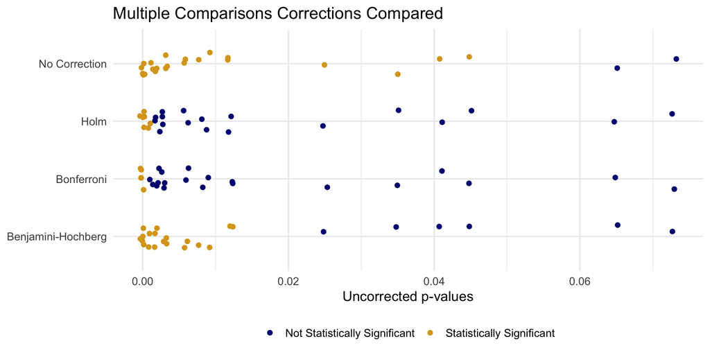

## Simulation Exercise

```r
# Loading the necessary packages
if(!require(mvtnorm)) install.packages(mvtnorm)
if(!require(randomizr)) install.packages(randomizr)

pacman::p_load(mvtnorm, randomizr)

# Helper functions (adapted from EGAP)
do_t_test <- function(Y, Z){
  t.test(Y[Z==1], Y[Z==0])$p.value
}
permute_treat <- function(){
  treatment_sim <- complete_ra(n, m=n/2)
  ps_sim <- apply(outcomes, 2, do_t_test, Z = treatment_sim)
  return(ps_sim)
}
threshold_finder<- function(threshold){
  mean(apply(many_ps, 2, x <- function(x) sum(x <= threshold) > 0 ))
}

# Seed for reproducibility
set.seed(37212)

# Generate correlated outcomes
# Outcomes are unrelated to treatment
# All null hypotheses are true
n <- 1000
k <- 100; r <- .7; s <- 1
sigma <- matrix(s*r, k,k)
diag(sigma) <- s
outcomes <- rmvnorm(n=n, mean=rep(0, k), sigma=sigma)

# Performing Random Assignment
treatment <- complete_ra(n, m=n/2)

# Conducting k hypothesis tests
p_obs <- apply(outcomes, 2, do_t_test, Z = treatment)

# Simulating under the sharp null
many_ps <- replicate(1000, permute_treat(), simplify = TRUE)

# Obtianing the Type I error rate across multiple thresholds
thresholds <- seq(0, 0.05, length.out = 1000)
type_I_rate <- sapply(thresholds, threshold_finder)

# Finding the largest threshold that yields an alpha type I error rate
target_p_value <- thresholds[max(which(type_I_rate <=0.05))]

# Applying that target p_value to the observed p_values
sig_simulated <- p_obs <= target_p_value

# Compare to raw p-values
sigs <- p_obs <= 0.05
```

## Outcomes of Simulation Exercise

1. The target $p$-value is $0.002$.
2. Only hypothesis tests with “raw” $p$-values below 0.002 are significant from this simulation.
3. Under the Bonferroni method, $\frac{0.05}{100} = 0.0005$ is the updated threshold for significance, so this is an improvement

Alexander Dean (Vanderbilt University)